# Countries of interest

This worksheet is part of a project to analyse and visualise data on the COVID-19 outbreak and will be run once a day.  
It shows data from a selection of countries deemed interesting through personal relations, as well as for interesting reference.

```python
import my_tools as mt

countries = ['China', 'France', 'Italy', 'United States of America', 'Spain', 'United Kingdom', 'Belgium', 'Iran', 'Ukraine', 'South Korea']
countries.sort()
```

```
Latest update at 2020-04-13
Latest data point at 2020-04-12
```

### Table

This table holds the latest information on each of the countries.

- Incidence = New cases / Population
- Prevalence = Total Cases / Popuulation
- Mortality = Total Deaths / Total cases

```python
mt.show_table(countries)
```

|  |  | Total | Prevalence | Mortality | Today | 3 days av | Weekly av | Incidence today | Incidence 3 days av | Incidence weekly av |
| --- | --- | --- | --- | --- | --- | --- | --- | --- | --- | --- |
| Global | Cases | 1734913 | 0.023% |  | 81707 | 86031 | 80078 | 0.001% | 0.001% | 0.001% |
|  | Deaths | 108192 |  | 6.236% | 6104 | 6792 | 6274 |  |  |  |
| Belgium | Cases | 28018 | 0.245% |  | 1351 | 1538 | 1369 | 0.012% | 0.013% | 0.012% |
|  | Deaths | 3346 |  | 11.942% | 327 | 368 | 294 |  |  |  |
| China | Cases | 83097 | 0.006% |  | 93 | 75 | 74 | 0.000% | 0.000% | 0.000% |
|  | Deaths | 3343 |  | 4.023% | 0 | 1 | 1 |  |  |  |
| France | Cases | 93790 | 0.140% |  | 3114 | 3914 | 3597 | 0.005% | 0.006% | 0.005% |
|  | Deaths | 13832 |  | 14.748% | 635 | 987 | 896 |  |  |  |
| Iran | Cases | 70029 | 0.086% |  | 1837 | 1814 | 2040 | 0.002% | 0.002% | 0.002% |
|  | Deaths | 4357 |  | 6.222% | 125 | 121 | 129 |  |  |  |
| Italy | Cases | 152271 | 0.252% |  | 4694 | 4283 | 3948 | 0.008% | 0.007% | 0.007% |
|  | Deaths | 19470 |  | 12.786% | 619 | 600 | 586 |  |  |  |
| South Korea | Cases | 10512 | 0.020% |  | 62 | 29 | 39 | 0.000% | 0.000% | 0.000% |
|  | Deaths | 214 |  | 2.036% | 6 | 3 | 4 |  |  |  |
| Spain | Cases | 161852 | 0.346% |  | 4830 | 5054 | 5302 | 0.010% | 0.011% | 0.011% |
|  | Deaths | 16353 |  | 10.104% | 510 | 599 | 658 |  |  |  |
| Ukraine | Cases | 2511 | 0.006% |  | 308 | 281 | 202 | 0.001% | 0.001% | 0.000% |
|  | Deaths | 73 |  | 2.907% | 4 | 7 | 6 |  |  |  |
| United Kingdom | Cases | 78991 | 0.119% |  | 8719 | 6086 | 5298 | 0.013% | 0.009% | 0.008% |
|  | Deaths | 9875 |  | 12.501% | 917 | 926 | 794 |  |  |  |
| United States of America | Cases | 529951 | 0.162% |  | 28391 | 32606 | 31102 | 0.009% | 0.010% | 0.010% |
|  | Deaths | 20608 |  | 3.889% | 1831 | 1930 | 1729 |  |  |  |

### Amount of cases, deaths

These plots show the amount of cases and deaths over time.

Do note that these numbers are reported by the countries, meaning they are accurate for as much as each country is testing their population. Though the confirmed cases will always be one or two weeks behind the actual numbers. As for the confirmed deaths, again countries can differ. Where, for example Belgium counts every death in the country due to COVID-19, Poland on the other hand only counts confirmed cases that died in the hospitals.  
Always keep these things in mind when looking at any COVID-19 data.

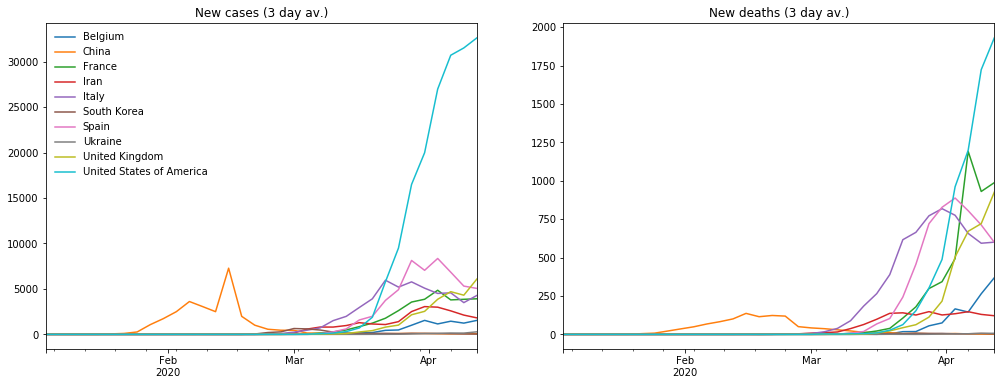

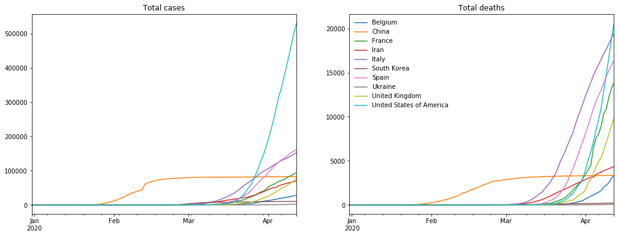

```python
mt.plot_spread('cases', '3days', countries)
mt.plot_spread('cases', 'total', countries, leg='r')
```

Since all of these trends are expronential, it is interesting to look at the on a logarithmic scale.This is mainly used to compare their exponential trends, represented by the angle of the line towards the x-axis. For this reason we will translate them over the x-axis in a way that each country starts from the point they had their first 100 cases, or 10 deaths. This makes them line up neatly to compare their angles.

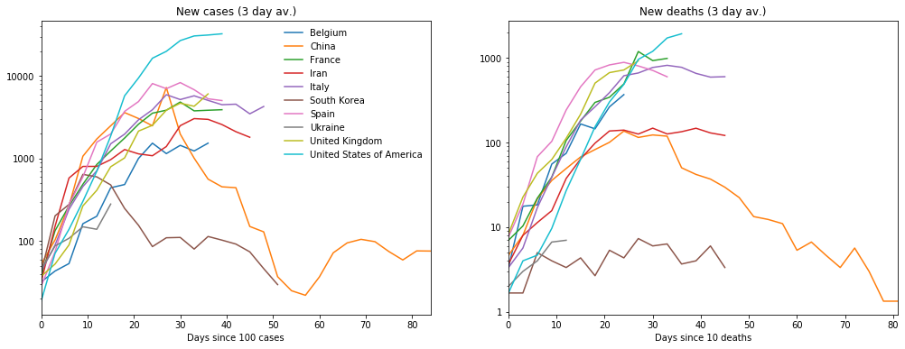

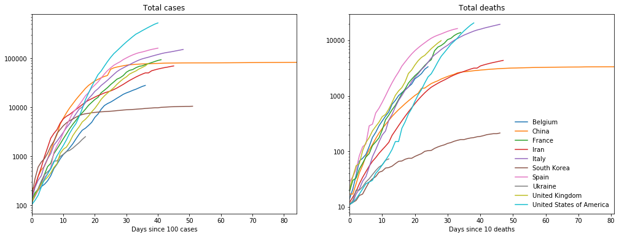

```python
mt.plot_spread('cases', '3days', countries, scale='log')
mt.plot_spread('cases', 'total', countries, scale='log', leg='r')
```

### Incidence and Prevalence

Since incidence and prevalence are relative to the population size, we can add the global information as a reference, mainly in the plot that are on the logarithmic scale, without messing up the scale of our plots.

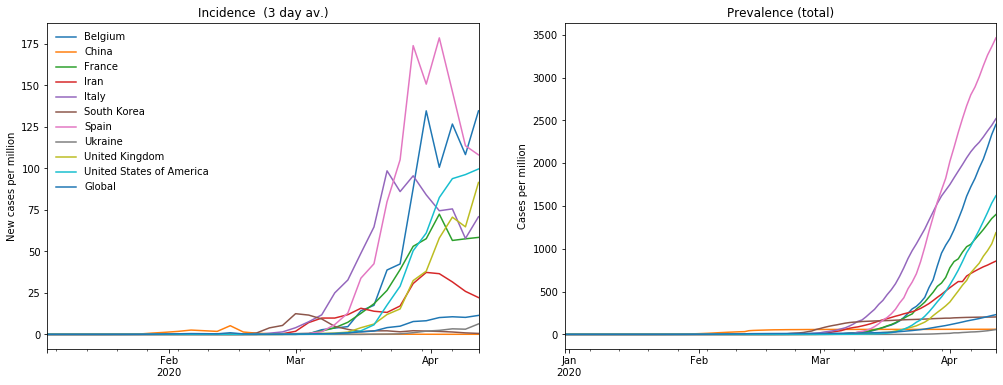

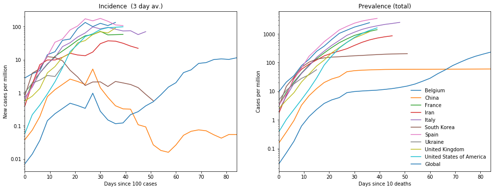

```python
countries.append('Global')

mt.plot_spread('incidence', '3days', countries)
mt.plot_spread('incidence', '3days', countries, scale='log', leg='r')
```

### Mortality

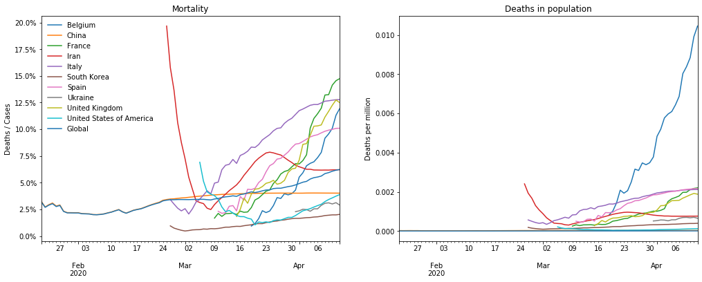

```python
mt.plot_mortality(countries)
```

### Trends

Show the growth rate compared to the total amount of cases, both relative to the population size.  
Considering time is respresented by how the countries move on the graph, an animated version of this graph, showing the progression over time, will also be saved in Dynamic-Trends/.

```
No handles with labels found to put in legend.
```

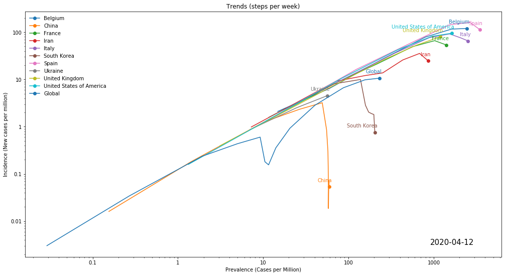

```python
mt.plot_trends_dynamically('countries_of_interest', countries)
```